# IPSR: Detect Influential Obseravation for Feature Rankings

Shuo Wang

November 08, 2023

# 1 Introduction

Feature rankings are a crucial aspect of analyzing high-throughput data, particularly for bioinformatics studies. These rankings are typically obtained by calculating the marginal correlation with the outcomes. The ordered feature list reflects the importance of features, which plays a vital role in guiding subsequent research. For instance, researchers usually focus on a small subset of important features that are associated with research objectives. However, the feature ranking can be distorted by a single case. The case exerts abnormal influence on the feature ranking is termed as influential points (IPs). The presence of IPs renders the feature ranking unreliable, consequently affecting the subsequent analysis based on feature rankings.

The *IPSR* R package is specifically designed to detect influential observations for feature rankings. The method utilized in this package is based on the leave-one-out strategy, which involves comparing the rank difference between the original ranking and a new ranking that is obtained by removing a single observation (1). Such new rankings are known as leave-one-out rankings. The rank difference obtained through this comparison helps to determine the influence of the deleted observation.

The whole process can be divided into three steps,

Step 1, generate the original and leave-one-out rankings using a feature ranking method, such as t-test. A dataset with n cases will result in one original ranking and n leave-one-out feature rankings.

Step 2, calculate rank changes. It is advisable to use top-prioritized weights when comparing ranks.

Step 3, calculate the cumulative rank changes for each observation. A diagnostic check is also required to identify any potential influential points.

# 2 Dataset

```r
library(IPSR)
data(miller05)
X <- miller05$X
y <- miller05$y
surv <- miller05$surv
```

# 3 Detect IPs using *getdrop1ranks()* and *sumRanks()*

We use a simple example where features are ranked based on t.test to demonstrate the use of *IPSR* package for IPs detection. We use *getdrop1ranks()* to derive the original ranking and leave-one-out rankings. Genes were simply ranked according to the p.values of t.test. Of note, the rank criteria is the p.value if *fun = “t.test”*. P.values were ranked in ascending order by specifying *decreasing = FALSE*. We selected the top 100 important genes in the original ranking. The returned object contains the original ranking (origRank) and a matrix of leave-one-out rankings (drop1Rank).

```r
obj <- getdrop1ranks(X, y, fun = "t.test", decreasing = FALSE, topN = 100)
str(obj)
```

```
#> List of 2
#>  $ origRank : chr [1:100] "202580_x_at" "205240_at" "205394_at" "212494_at" ...
#>  $ drop1Rank: chr [1:100, 1:236] "202580_x_at" "205240_at" "205394_at" "212494_at" ...
#>   ..- attr(*, "dimnames")=List of 2
#>   .. ..$ : NULL
#>   .. ..$ : chr [1:236] "GSM79114" "GSM79115" "GSM79116" "GSM79118" ...
```

After obtaining the original ranking and leave-one-out rankings using the *getdrop1ranks()* function, we use the *sumRanks()* function to compute the distance between them. This function provides three methods for comparing ranks: unweighted, weighted Spearman, and method with adaptive weights. The unweighted method directly compares the ranks and assumes that all ranks have equal importance. However, this is not always the case as the top-ranked methods are usually more important. The weighted Spearman and adaptive weights methods address this issue by emphasizing the importance of the top-ranked methods (3). The adaptive weights method can further adjust the weights based on the distribution of rank changes in the data.

```r
results <- sumRanks(origRank = obj$origRank, drop1Rank = obj$drop1Rank, topN = 100,
    method = "adaptive")

str(results)
```

```
#> List of 6
#>  $ kappa            : num 0.0226
#>  $ score            : Named num [1:236] 0.968 3.404 3.066 2.776 1.09 ...
#>   ..- attr(*, "names")= chr [1:236] "GSM79114" "GSM79115" "GSM79116" "GSM79118" ...
#>  $ origRank         : chr [1:100] "202580_x_at" "205240_at" "205394_at" "212494_at" ...
#>  $ drop1Rank        : int [1:100, 1:236] 1 2 3 4 6 5 7 8 9 10 ...
#>   ..- attr(*, "dimnames")=List of 2
#>   .. ..$ : NULL
#>   .. ..$ : chr [1:236] "GSM79114" "GSM79115" "GSM79116" "GSM79118" ...
#>  $ origRankWeighted : num [1:100] 0.025 0.0244 0.0239 0.0233 0.0228 ...
#>  $ drop1RankWeighted: num [1:100, 1:236] 0.025 0.0244 0.0239 0.0233 0.0223 ...
#>   ..- attr(*, "dimnames")=List of 2
#>   .. ..$ : NULL
#>   .. ..$ : chr [1:236] "GSM79114" "GSM79115" "GSM79116" "GSM79118" ...
#>  - attr(*, "class")= chr [1:2] "list" "ips"
```

The outputs of *sumRanks()* are diverse across the selected methods. For *method = “adaptive”*, *sumRanks()* returns a list with the following elements:

1, kappa, the shape parameter of the adaptive weights method;  
2, score, the accumulated weighted rank changes, reflecting the influence of each sample; 3, origRank, the original ranking; 4, drop1Rank, the leave-one-out rankings;  
5, origRankWeighted, weighted original ranking;  
6, drop1RankWeighted, weighted leave-one-out rankings.

# 4 Use *ipsr()* to detect IPs in one-step

*ipsr()* combines *getdrop1ranks()* and *sumRanks()* into one step. The output is identical to using the two-step process.

```r
results.ipsr <- ipsr(X, y, fun = "t.test", decreasing = FALSE, method = "adaptive")

identical(results, results.ipsr)
```

```
#> [1] TRUE
```

# 5 Results visualization

*IPSR* package offers three visualization functions: *plot.ips()*, *plotRankScatters()*, and *plotAdaptiveWeights()*. *plot.ips()* can directly utilize the output of *ipsr()* or *sumRanks()* to creat a lollipop plot that displays the influence of each case. In Figure 1, we can see that the observation 68 (obs68) seems to be more influential on the final results. However, the difference between obs68 and the other observations is not that distinct, indicating a lower possibility of the presence of an influential observation.

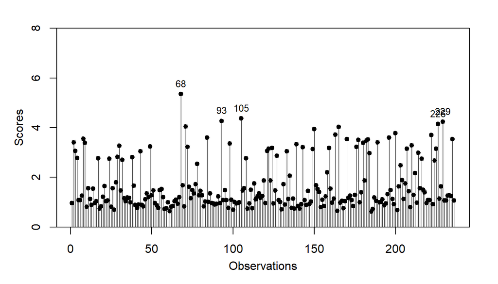

Figure 1, the influence scores for each observation

```r
par(mar = c(4, 4, 2, 2))
plot(results.ipsr, topn = 5, ylim = c(0, 8))
```

In addition to the lollipop, *IPSR* also provides a simple visualization function *plotRankScatters()* that exhibits the distribution of rank changes using a scatter plot (Figure 2). Alike *plot.ips()*, *plotRankScatters()* simply use the output of *ipsr()* or *sumRanks()*. According to Figure 2, we can observe more rank changes in the tail side, but less changes in the head. The black points denotes the rank changes caused by the most influential case.

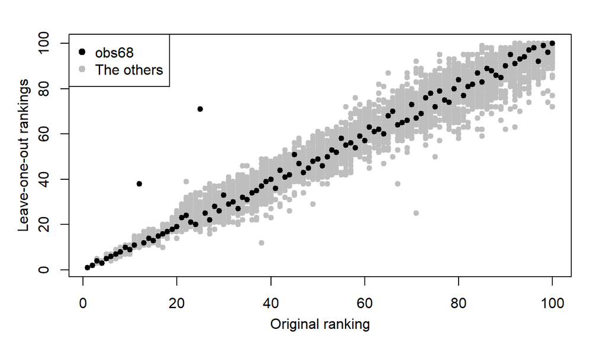

Figure 2, the distribution of rank changes

```r
par(mar = c(4, 4, 2, 2))
plotRankScatters(results.ipsr)
```

The *plotAdaptiveWeights()* function aims to Visualize weight function if adaptive weights are used for rank comparison, that is *method = “adaptive”* for *ipsr()* or *sumRanks()*. The argument *kappa* refers to the shape parameter of the weight function. Here, the optimized kappa is 0.023 (Figure 3). n is the length of the feature list. We select the top 100 features, hence, *n = 100*. We can observe that more weights are allocated to the top-ranked features.

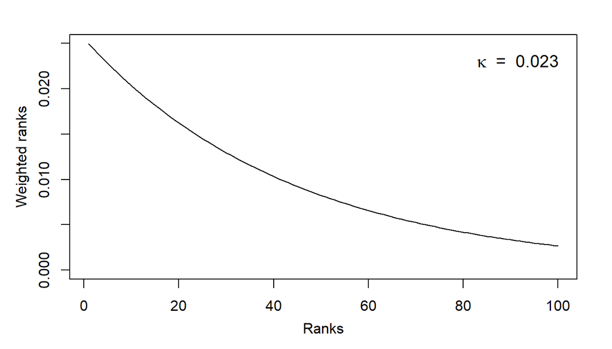

Figure 3, the weight function of the adaptive weights

```r
par(mar = c(4, 4, 2, 2))
plotAdaptiveWeights(results.ipsr$kappa, n = 100, type = "line")
```

# 6 Use IPSR in survival data

For survival analysis, we offer the option to rank features using univariate Cox model by setting *fun = “cox”*. The features are ranked in ascending order based on their P-values.

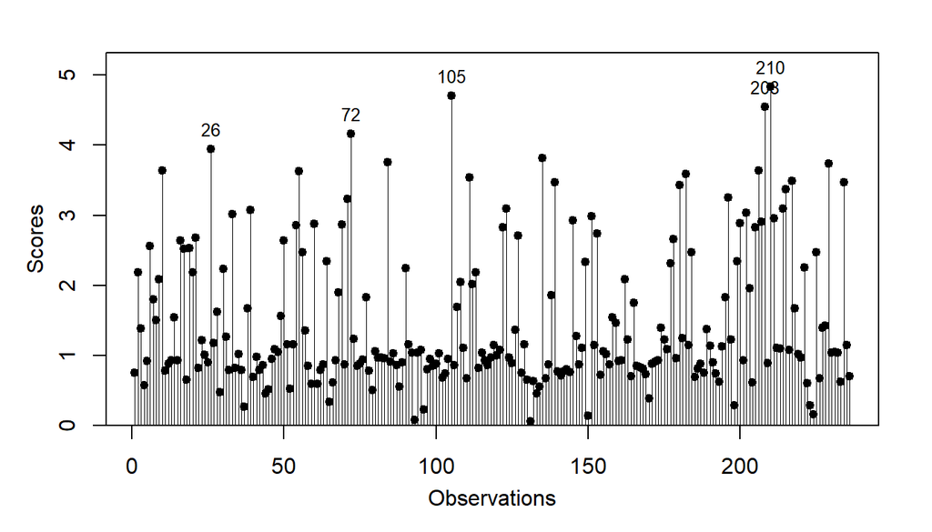

Figure 4, IPs detection for survival data

```r
par(mar = c(4, 4, 2, 2))
results.cox <- ipsr(X, surv, fun = "cox", decreasing = FALSE, method = "adaptive")

plot(results.cox)
```

# 7 Define the rank criteria

In addtion to the provided ranking criteria in *ipsr()* or *sumRanks()*, which includes “t.test”, “cox”, “log2fc”, and “kruskal.test”. We can also use a custom function to rank features based on a specified rank criterion. To this end, we can pass the custom function to the *fun* argument. The function should take *x* and *y* as inputs and output the rank criterion, such as p-values.

As an example, we can rank features based on the p-values obtained from the kruskal.test. We can either specify *fun = “kruskal.test”*, as this test has been implemented in the package, or define our own function to pass to *getdrop1ranks*. Both methods produce the same results.

```r
fun <- function(x, y) {
    kruskal.test(x, y)$p.value
}

kruskal.test1 <- getdrop1ranks(X, y, fun = fun, decreasing = F)

kruskal.test2 <- getdrop1ranks(X, y, fun = "kruskal.test", decreasing = F)

identical(kruskal.test1, kruskal.test2)
```

```
#> [1] TRUE
```

# 8 The choice of rank comparison methods

*IPSR* provides three rank comparison methods: unweighted, weighted Spearman, and adaptive weights. We recommend using the adaptive weights. Here, we compare the three methods. Weighted Spearman and the adaptive weights method demonstrates similar results. But both are differnt weight the unweighted method.

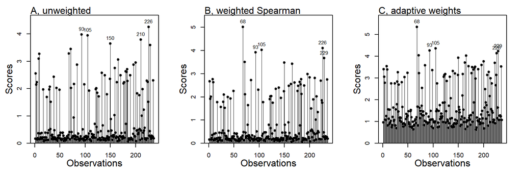

Figure 5, IPs detection using three rank comparison methods

```r
re.unweighted <- ipsr(X, y, fun = "t.test", decreasing = FALSE, method = "unweighted")
re.weighted <- ipsr(X, y, fun = "t.test", decreasing = FALSE, method = "weightedSpearman")
re.adaptive <- ipsr(X, y, fun = "t.test", decreasing = FALSE, method = "adaptive")

par(mfrow = c(1, 3), mar = c(4, 4, 2, 2))
plot(re.unweighted)
mtext("A, unweighted", side = 3, line = 0, adj = 0)
plot(re.weighted)
mtext("B, weighted Spearman", side = 3, line = 0, adj = 0)
plot(re.adaptive)
mtext("C, adaptive weights", side = 3, line = 0, adj = 0)
```

# 9 Reference

1, Wang, Shuo, and Junyan Lu. “Detect influential points of feature rankings.” arXiv preprint arXiv:2303.10516 (2023).  
2, Miller, Lance D., et al. “An expression signature for p53 status in human breast cancer predicts mutation status, transcriptional effects, and patient survival.” Proceedings of the National Academy of Sciences 102.38 (2005): 13550-13555.doi:10.1073pnas.0506230102 3, Da Pinto Costa, Joaquim; Soares, Carlos (2005): A weighted rank measure of correlation. In Australian & New Zealand Journal of Statistics 47 (4), pp. 515–529.